# Prediction Assignment Writeup

Vitalii

12/08/2020

# Overview

One thing that people regularly do is quantify how much of a particular activity they do, but they rarely quantify how well they do it. In this project, your goal will be to use data from accelerometers on the belt, forearm, arm, and dumbell of 6 participants.

The goal of this project is to predict the manner in which they did the exercise. This is the “classe” variable in the training set.

The data for this project come from this source: http://web.archive.org/web/20161224072740/http:/groupware.les.inf.puc-rio.br/har.

# Loading and preprocessing the data

Download all the necessary packages for further work.

```r
library(caret)
library(e1071)
```

Now let’s move on to downloading the dataset.

```r
trainUrl <- "https://d396qusza40orc.cloudfront.net/predmachlearn/pml-training.csv"
testUrl  <- "https://d396qusza40orc.cloudfront.net/predmachlearn/pml-testing.csv"
trainFile <- "pml-traininig.csv"
testFile <- "pml-testing.csv"

# download the datasets
if(!file.exists(trainFile)) {
        download.file(trainUrl, destfile = trainFile)
        }

train <- read.csv(trainFile)

if(!file.exists(testFile)) {
        download.file(testUrl, destfile = testFile)
        }

test <- read.csv(testFile)
```

The data set is cleared of identification variables, variables with low variation and variables with many omitted values.

```r
# remove identification variables
train <- train[, -(1:5)]
train$classe <- as.factor(train$classe)

# create a partition using caret with the training dataset
inTrain  <- createDataPartition(train$classe, p = 0.7, list = FALSE)
trainSet <- train[inTrain, ]
testSet <- train[-inTrain, ]
dim(trainSet)
```

```
## [1] 13737   155
```

```r
dim(testSet)
```

```
## [1] 5885  155
```

```r
# remove variables with Nearly Zero Variance
NZV <- nearZeroVar(trainSet)
trainSet <- trainSet[, -NZV]
testSet  <- testSet[, -NZV]
dim(trainSet)
```

```
## [1] 13737   102
```

```r
dim(testSet)
```

```
## [1] 5885  102
```

```r
# remove variables that are mostly NA
allNA    <- sapply(trainSet, function(x) mean(is.na(x))) > 0.95
trainSet <- trainSet[, allNA == FALSE]
testSet  <- testSet[, allNA == FALSE]
dim(trainSet)
```

```
## [1] 13737    54
```

```r
dim(testSet)
```

```
## [1] 5885   54
```

Make the plot of distribution of classes.

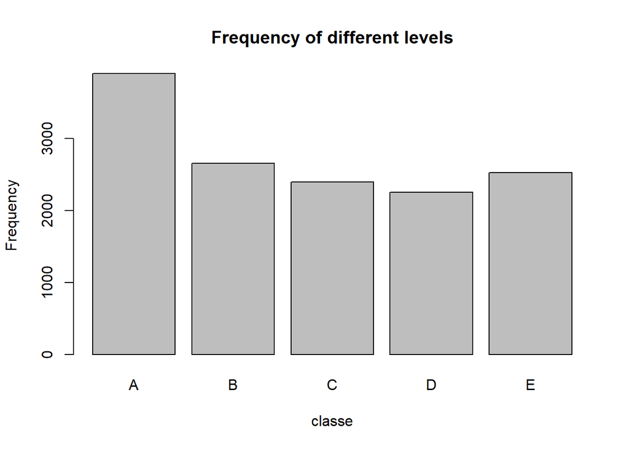

```r
plot(trainSet$classe,
     main = "Frequency of different levels",
     xlab = "classe", ylab = "Frequency")
```

Based on the frequency distribution, it shows that each level frequency is within the same order of magnitude of each other. Level A is the most frequent, and level D is the least frequent.

# Predictive modelling

The model of Random Forest was chosen for predictive modelling, because according to the literature, this approach has proven to be the best. On the other hand, this approach is quite time consuming during training.

```r
controlRF <- trainControl(method = "cv", number = 3, verboseIter = FALSE)
RF_model <- train(classe ~ .,
                  data = trainSet,
                  method = "rf",
                  trControl = controlRF)

RF_model$finalModel
```

```
##
## Call:
##  randomForest(x = x, y = y, mtry = param$mtry)
##                Type of random forest: classification
##                      Number of trees: 500
## No. of variables tried at each split: 27
##
##         OOB estimate of  error rate: 0.18%
## Confusion matrix:
##      A    B    C    D    E  class.error
## A 3904    2    0    0    0 0.0005120328
## B    5 2650    3    0    0 0.0030097818
## C    0    6 2390    0    0 0.0025041736
## D    0    0    8 2244    0 0.0035523979
## E    0    1    0    0 2524 0.0003960396
```

```r
predictRF <- predict(RF_model, newdata = testSet)
confMatRF <- confusionMatrix(predictRF, testSet$classe)
confMatRF
```

```
## Confusion Matrix and Statistics
##
##           Reference
## Prediction    A    B    C    D    E
##          A 1674    3    0    0    0
##          B    0 1135    1    0    2
##          C    0    1 1025    5    0
##          D    0    0    0  959    2
##          E    0    0    0    0 1078
##
## Overall Statistics
##
##                Accuracy : 0.9976
##                  95% CI : (0.996, 0.9987)
##     No Information Rate : 0.2845
##     P-Value [Acc > NIR] : < 2.2e-16
##
##                   Kappa : 0.997
##
##  Mcnemar's Test P-Value : NA
##
## Statistics by Class:
##
##                      Class: A Class: B Class: C Class: D Class: E
## Sensitivity            1.0000   0.9965   0.9990   0.9948   0.9963
## Specificity            0.9993   0.9994   0.9988   0.9996   1.0000
## Pos Pred Value         0.9982   0.9974   0.9942   0.9979   1.0000
## Neg Pred Value         1.0000   0.9992   0.9998   0.9990   0.9992
## Prevalence             0.2845   0.1935   0.1743   0.1638   0.1839
## Detection Rate         0.2845   0.1929   0.1742   0.1630   0.1832
## Detection Prevalence   0.2850   0.1934   0.1752   0.1633   0.1832
## Balanced Accuracy      0.9996   0.9979   0.9989   0.9972   0.9982
```

A Confusion Matrix is plotted to better visualize the accuracy of the model.

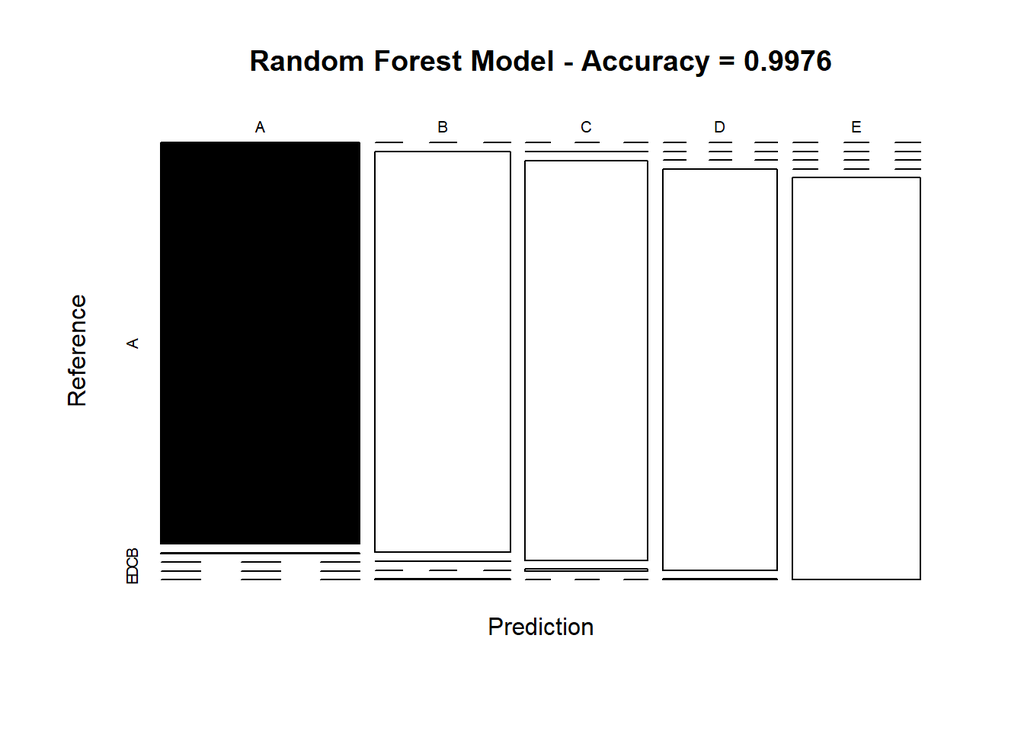

```r
plot(confMatRF$table, col = confMatRF$byClass,
     main = paste("Random Forest Model - Accuracy =",
                  round(confMatRF$overall['Accuracy'], 4)))
```

```r
predictTEST <- predict(RF_model, newdata = test)
predictTEST
```

```
##  [1] B A B A A E D B A A B C B A E E A B B B
## Levels: A B C D E
```